# Unit R.B: Normal & CTL in R

Instructor: Dr. Md Mutasim Billah

# Purpose and how to use this activity

This activity introduces **base R** commands for finding Normal and Student’s $t$ probabilities, cutoff values, confidence intervals, and hypothesis-test results. **No additional R packages are required.** You can run each code chunk in RStudio.

**A reminder for STAT 312**

R is a tool for evaluating probabilities and quantiles. **You still need to identify the appropriate distribution, define the event, check assumptions, and interpret the result.** Use your class notes, lecture notes (when available), quizzes, required practice problems, and homework assignments to prepare for assessments.

## Four essential distribution commands

- `pnorm(x)` gives $P(Z\le x)$ for a standard Normal random variable.
- `qnorm(p)` returns the $z$-value with **left-tail area** $p$: $P(Z\le z)=p$.
- `pt(t, df)` gives $P(T\le t)$ for a $t$ distribution with `df` degrees of freedom.
- `qt(p, df)` returns the $t$-value with **left-tail area** $p$.

For right-tail probabilities, use `lower.tail = FALSE`. For an arbitrary Normal distribution, specify `mean` and `sd` in `pnorm()` or `qnorm()`.

```r
# Standard Normal: P(Z < 1.25), P(Z > 1.25), and its 95th percentile
pnorm(1.25)
## [1] 0.8943502
pnorm(1.25, lower.tail = FALSE)
## [1] 0.1056498
qnorm(0.95)
## [1] 1.644854

# Student's t with 10 degrees of freedom
df <- 10
pt(1.25, df = df)
## [1] 0.8801197
pt(1.25, df = df, lower.tail = FALSE)
## [1] 0.1198803
qt(0.95, df = df)
## [1] 1.812461
```

**R’s conventions**

For continuous distributions, $P(Z < z)=P(Z\le z)$, so the strict versus non-strict inequality does not affect `pnorm()` results. R gives more precise numerical answers than a printed table; note that in the exam you will need to use the table, however.

# Finding Z and t critical values directly in R

## Z critical values and tail probabilities

```r
# Common two-sided Normal critical values
qnorm(0.95)   # 90% confidence interval -> 1.645
## [1] 1.644854
qnorm(0.975)  # 95% confidence interval -> 1.960
## [1] 1.959964
qnorm(0.995)  # 99% confidence interval -> 2.576
## [1] 2.575829

# Left-tail alpha = 0.05 rejection cutoff
qnorm(0.05)
## [1] -1.644854

# Right-tail alpha = 0.05 rejection cutoff
qnorm(0.05, lower.tail = FALSE)
## [1] 1.644854

# Calculate a two-sided p-value for an observed z = -2.10
z_obs <- -2.10
2 * pnorm(abs(z_obs), lower.tail = FALSE)
## [1] 0.03572884
```

## t critical values and tail probabilities

**Always specify the degrees of freedom.** The $t$ critical value depends on `df`.

```r
n <- 16
df <- n - 1

# Critical t for a 95% two-sided confidence interval
t_crit <- qt(0.975, df = df)
round(t_crit, 3)
## [1] 2.131

# Left-tailed test, significance level 0.05
round(qt(0.05, df = df), 3)
## [1] -1.753

# Right-tailed test, significance level 0.05
round(qt(0.05, df = df, lower.tail = FALSE), 3)
## [1] 1.753

# P(T < -1.20), P(T > 1.20), and P(-1.20 < T < 1.20)
round(pt(-1.20, df = df), 4)
## [1] 0.1244
round(pt(1.20, df = df, lower.tail = FALSE), 4)
## [1] 0.1244
round(pt(1.20, df = df) - pt(-1.20, df = df), 4)
## [1] 0.7513
```

# Group Works:

- Make sure you are synchronized in a group of at least two students.
- Download the .qmd file for this activity here and open in R-studio.
- Work through the following examples that we have discussed in the class - it is highly recommended you have your solved handouts with you or download the solved one from the Canvas.
- Work in a group, share your thoughts.
- I will be moving around, raise your hand if you have any question!

### Classroom practice: place a bound on a t-test p-value

For a **left-tailed** test with observed $t=-1.20$ and $df=5$, find the exact p-value and compare with the table-based bound.

```r
t_obs <- -1.20
df <- 5
p_exact <- pt(t_obs, df = df)

round(p_exact, 4)
## [1] 0.1419

# Left-tail critical t values for areas 0.10 and 0.20
round(c(`10% left tail` = qt(0.10, df = df),
        `20% left tail` = qt(0.20, df = df)), 3)
## 10% left tail 20% left tail
##        -1.476        -0.920
```

Since $qt(0.10,5)\approx-1.476<-1.20<qt(0.20,5)\approx-0.920$, the table gives **$0.10<p<0.20$**. R gives the more precise value, about $0.142$.

**Other useful R distribution commands**

`dnorm(x)` and `dt(x, df)` calculate **density heights**, not tail probabilities. `rnorm(n)` and `rt(n, df)` generate random values. Use `pnorm()`/`pt()` for areas and `qnorm()`/`qt()` for cutoffs.

# Part IV. Confidence intervals in R (supplementary examples)

These worked examples extend beyond the attached Unit 06 handout. They show how to use the same R commands in our confidence-interval topics.

## Example CI-1: Population mean, known population SD (Z interval)

**New illustrative example inspired by the newborn-mass setting.** Suppose a random independent sample of $n=100$ newborns has sample mean $\bar y=3420$ grams and the population SD is known to be $\sigma=500$ grams. Find a 95% confidence interval for $\mu$.

$$\bar y\pm z_{\alpha/2}\frac{\sigma}{\sqrt n}.$$

```r
xbar <- 3420
sigma <- 500
n <- 100
confidence <- 0.95

alpha <- 1 - confidence
z_star <- qnorm(1 - alpha / 2)
se <- sigma / sqrt(n)
me <- z_star * se
ci <- c(lower = xbar - me, upper = xbar + me)

round(z_star, 3)
## [1] 1.96
round(me, 2)
## [1] 98
round(ci, 2)
## lower upper
##  3322  3518
```

## Example CI-2: Population mean, unknown population SD (t interval)

**Example reused from our STAT 312 hypothesis-testing practice:** A random sample of 41 people with unpaid parking tickets has mean age $\bar x=35.6$ and sample standard deviation $s=11.5$ years. Construct a 95% two-sided confidence interval, assuming the observations are independent and a t-based procedure is reasonable.

$$\bar x\pm t_{\alpha/2,n-1}\frac{s}{\sqrt n}.$$

```r
n <- 41
xbar <- 35.6
s <- 11.5
confidence <- 0.95

df <- n - 1
t_star <- qt((1 + confidence) / 2, df = df)
se <- s / sqrt(n)
me <- t_star * se
ci <- c(lower = xbar - me, upper = xbar + me)

round(t_star, 3)
## [1] 2.021
round(me, 3)
## [1] 3.63
round(ci, 3)
## lower upper
## 31.97 39.23

# R's built-in t.test() can calculate this CI from raw data,
# but xbar, s, and n alone are enough for the manual formula above.
```

## Example CI-3: Population proportion (Normal approximation)

**New illustrative example.** In an independent random sample of 200 people, 112 answer “yes.” Estimate the population proportion $p$ with a 95% confidence interval.

$$\widehat p\pm z_{\alpha/2}
\sqrt{\frac{\widehat p(1-\widehat p)}{n}}.$$

```r
n <- 200
successes <- 112
p_hat <- successes / n

# Check the course guideline for this Normal approximation
c(successes = n * p_hat,
  failures = n * (1 - p_hat))
## successes  failures
##       112        88

z_star <- qnorm(0.975)
se_hat <- sqrt(p_hat * (1 - p_hat) / n)
ci <- p_hat + c(-1, 1) * z_star * se_hat

round(p_hat, 4)
## [1] 0.56
round(setNames(ci, c("lower", "upper")), 4)
##  lower  upper
## 0.4912 0.6288
```

# Part V. Hypothesis testing in R (supplementary examples)

In each test, **state $H_0$ and $H_a$ first**, then compute the test statistic and p-value. Compare the p-value with $\alpha$ and write a conclusion in the context of the problem.

## Example HT-1: Left-tailed t-test for average age

**Previously discussed STAT 312 practice example:** For people with unpaid parking tickets, suppose $n=41$, $\bar x=35.6$, and $s=11.5$. Test

$$H_0:\mu=37\quad\text{vs.}\quad H_a:\mu<37$$

at $\alpha=0.05$. Because $\sigma$ is unknown, use a one-sample $t$ test with 40 degrees of freedom (subject to the usual sampling assumptions).

```r
n <- 41
xbar <- 35.6
s <- 11.5
mu0 <- 37
alpha <- 0.05

df <- n - 1
t_obs <- (xbar - mu0) / (s / sqrt(n))
p_value <- pt(t_obs, df = df)  # LEFT-tailed p-value
critical_t <- qt(alpha, df = df)

round(t_obs, 3)       # Approximately -0.780
## [1] -0.78
round(critical_t, 3)  # Approximately -1.684
## [1] -1.684
round(p_value, 4)     # Approximately 0.2201
## [1] 0.2201

if (p_value < alpha) {
  cat("Reject H0 at alpha =", alpha, "\n")
} else {
  cat("Fail to reject H0 at alpha =", alpha, "\n")
}
## Fail to reject H0 at alpha = 0.05
```

**Interpretation:** Since $p\approx0.2201>0.05$, there is insufficient evidence to conclude that the population mean age is less than 37 years.

### How does the p-value change for a two-sided alternative?

If instead $H_a:\mu\ne37$, the test statistic stays the same but the two-sided p-value changes.

```r
p_two_sided <- 2 * pt(abs(t_obs), df = df, lower.tail = FALSE)
round(p_two_sided, 4)
## [1] 0.4403
```

**Remember:** Never choose a one-sided versus two-sided alternative *after* looking at the data. The alternative should be determined by the research question in advance.

## Example HT-2: Right-tailed Z-test when the population SD is known

**New illustrative example inspired by the newborn-mass setting.** Suppose the established population SD is $500$ grams. A random independent sample of $100$ newborns has mean mass $3500$ grams. At $\alpha=0.05$, test

$$H_0:\mu=3400\quad\text{vs.}\quad H_a:\mu>3400.$$

```r
xbar <- 3500
mu0 <- 3400
sigma <- 500
n <- 100
alpha <- 0.05

z_obs <- (xbar - mu0) / (sigma / sqrt(n))
p_value <- pnorm(z_obs, lower.tail = FALSE)
critical_z <- qnorm(alpha, lower.tail = FALSE)

round(z_obs, 3)
## [1] 2
round(critical_z, 3)
## [1] 1.645
round(p_value, 4)
## [1] 0.0228

if (p_value < alpha) {
  cat("Reject H0: evidence supports a mean above 3400 grams.\n")
} else {
  cat("Fail to reject H0: insufficient evidence of a mean above 3400 grams.\n")
}
## Reject H0: evidence supports a mean above 3400 grams.
```

## A reusable R template for one-sample mean tests

Use this template for **summary statistics**. Set `alternative` to `"less"`, `"greater"`, or `"two.sided"`. Choose `sigma` only when the **population** standard deviation is known; otherwise use the sample SD `s`.

```r
# Example inputs: edit these for a different problem
xbar <- 35.6
mu0 <- 37
n <- 41
s <- 11.5
sigma_known <- FALSE
alpha <- 0.05
alternative <- "less"  # "less", "greater", or "two.sided"

stopifnot(n > 1, alternative %in% c("less", "greater", "two.sided"))

if (sigma_known) {
  sigma <- 11.5  # Replace with the KNOWN population SD when applicable
  statistic <- (xbar - mu0) / (sigma / sqrt(n))
  cdf <- function(x, lower.tail = TRUE) pnorm(x, lower.tail = lower.tail)
  distribution <- "Z"
} else {
  statistic <- (xbar - mu0) / (s / sqrt(n))
  cdf <- function(x, lower.tail = TRUE) pt(x, df = n - 1,
                                          lower.tail = lower.tail)
  distribution <- "t"
}

p_value <- switch(
  alternative,
  less = cdf(statistic),
  greater = cdf(statistic, lower.tail = FALSE),
  two.sided = 2 * cdf(abs(statistic), lower.tail = FALSE)
)

cat("Distribution:", distribution, "\n")
## Distribution: t
cat("Test statistic:", round(statistic, 4), "\n")
## Test statistic: -0.7795
cat("p-value:", round(p_value, 5), "\n")
## p-value: 0.22013
cat(if (p_value < alpha) "Reject H0\n" else "Fail to reject H0\n")
## Fail to reject H0
```

# Quick reference: which R command do I need?

- **Probability to the left:** `pnorm(value)` or `pt(value, df)`.
- **Probability to the right:** `pnorm(value, lower.tail = FALSE)` or `pt(value, df, lower.tail = FALSE)`.
- **Probability between two values:** `pnorm(upper) - pnorm(lower)` or `pt(upper, df) - pt(lower, df)`.
- **A cutoff from a left-tail area:** `qnorm(area)` or `qt(area, df)`.
- **A cutoff from a right-tail area:** `qnorm(area, lower.tail = FALSE)` or `qt(area, df, lower.tail = FALSE)`.
- **A central $100(1-\alpha)\%$ critical value:** `qnorm(1 - alpha/2)` or `qt(1 - alpha/2, df)`.
- **A sampling distribution for a mean:** replace `sd = sigma` by `sd = sigma/sqrt(n)` when using Normal approximations.

**Common mistakes to avoid**

1. Using `qnorm()` when the question asks for a probability; use `pnorm()` for probabilities and `qnorm()` for cutoffs.
2. Forgetting `lower.tail = FALSE` for right-tailed probabilities.
3. Using the SD of individual observations ($\sigma$) instead of the standard error ($\sigma/\sqrt n$) for $\overline Y$.
4. Using `pnorm()` when the correct test statistic follows a $t$ distribution; specify `df = n - 1` in `pt()` and `qt()`.
5. Treating a p-value as the probability that $H_0$ is true. It is **not** that probability.
6. Treating a nonsignificant result as proof of $H_0$. Say **“fail to reject $H_0$”** instead.

# Try it yourself

Before running R, decide which function and tail you need. Then check your result in R.

**Show R code for self-checking**

```r
round(pnorm(1.35, lower.tail = FALSE), 4)
## [1] 0.0885
round(pnorm(1.80) - pnorm(-0.50), 4)
## [1] 0.6555
round(qnorm(0.025, lower.tail = FALSE), 4)
## [1] 1.96
round(qt(0.05, df = 20, lower.tail = FALSE), 4)
## [1] 1.7247
round(2 * pt(1.20, df = 5, lower.tail = FALSE), 4)
## [1] 0.2839
round(pnorm(1, mean = 1.02, sd = 0.01 / sqrt(4)), 6)
## [1] 3.2e-05

mu_uniform <- (2.97 + 3.01) / 2
sigma_uniform <- (3.01 - 2.97) / sqrt(12)
se_100 <- sigma_uniform / sqrt(100)
round(pnorm(2.991, mean = mu_uniform, sd = se_100) -
      pnorm(2.987, mean = mu_uniform, sd = se_100), 4)
## [1] 0.8021
```

# Unit 07: Confidence Intervals in R

In Unit 06, we learned how to calculate probabilities and critical values using R. We will now use those functions to construct and interpret **confidence intervals**.

Our goal is to learn how to use R instead of printed Z- and t-tables.

The main functions are:

- `qnorm()` finds critical Z-values.
- `qt()` finds critical t-values.
- `pnorm()` finds probabilities from a normal distribution.
- `pt()` finds probabilities from a t-distribution.
- `sqrt()` calculates square roots.
- `ceiling()` rounds a number upward to an integer.

**Important:** R uses more decimal places than the printed tables. Therefore, some answers may differ slightly from those obtained in class using rounded critical values.

## Example 1: Confidence Interval for a Population Mean When $\sigma$ Is Known

Suppose the sample mean $\overline{Y}$ has a normal or approximately normal sampling distribution:

$$\overline{Y}\sim N\left(\mu,\frac{\sigma}{\sqrt{n}}\right).$$

Assume the population standard deviation $\sigma$ is known.

### (a) Construct a 95% confidence interval for $\mu$

Recall that

$$Z=\frac{\overline{Y}-\mu}{\sigma/\sqrt{n}}.$$

For a 95% confidence interval,

$$\alpha=1-0.95=0.05.$$

Each tail contains probability

$$\frac{\alpha}{2}=0.025.$$

We need the critical value satisfying

$$P(Z<z_{0.025})=0.975.$$

In R, use `qnorm()`:

```r
# Confidence level
conf_level <- 0.95

# Significance level
alpha <- 1 - conf_level

# Find the critical Z-value
z_critical <- qnorm(1 - alpha / 2)

z_critical
## [1] 1.959964

# The corresponding negative critical value
-z_critical
## [1] -1.959964
```

We should obtain approximately

$$z_{0.025}=1.96.$$

Let us verify that the area between $-1.96$ and $1.96$ is approximately 0.95.

```r
# Probability between the two critical values
pnorm(z_critical) - pnorm(-z_critical)
## [1] 0.95
```

Therefore,

$$P(-1.96<Z<1.96)\approx0.95.$$

The resulting 95% confidence interval is

$$\boxed{
\overline{y}\pm1.96\frac{\sigma}{\sqrt{n}}
}$$

Notice that we have not yet used actual sample values. We have simply obtained the critical value necessary to construct the interval.

### (b) Generalize to a $(1-\alpha)100\%$ confidence interval

For any confidence level $1-\alpha$, we can obtain the critical value using

```r
# Example: 90%, 95%, and 99% confidence levels

qnorm(0.95)   # 90% CI: 5% in each tail
## [1] 1.644854

qnorm(0.975)  # 95% CI: 2.5% in each tail
## [1] 1.959964

qnorm(0.995)  # 99% CI: 0.5% in each tail
## [1] 2.575829
```

The general formula is

$$\boxed{
\overline{y}\pm z_{\alpha/2}\frac{\sigma}{\sqrt{n}}
}$$

where

$$z_{\alpha/2}
=
\texttt{qnorm}(1-\alpha/2).$$

We can define a reusable R function:

```r
# Function for a Z-based confidence interval
# when population standard deviation is known

ci_mean_z <- function(xbar, sigma, n, conf_level = 0.95) {

  alpha <- 1 - conf_level

  z_critical <- qnorm(1 - alpha / 2)

  SE <- sigma / sqrt(n)

  ME <- z_critical * SE

  lower <- xbar - ME
  upper <- xbar + ME

  return(c(lower = lower, upper = upper))
}
```

We will use this function in the next examples.

## Example 2: Confidence Interval for Mean Weight of CWRU Students

We are interested in the population mean weight $\mu$ among all CWRU students.

Suppose we have the following information:

- Sample size: $n=30$
- Sample mean: $\overline{y}=150$ pounds
- Known population standard deviation: $\sigma=25$ pounds
- Confidence level: 95%

Construct a 95% confidence interval for $\mu$.

The formula is

$$\overline{y}\pm z_{\alpha/2}\frac{\sigma}{\sqrt{n}}.$$

### Step 1: Enter the information

```r
n <- 30
xbar <- 150
sigma <- 25
conf_level <- 0.95
```

### Step 2: Find the critical Z-value

```r
alpha <- 1 - conf_level

z_critical <- qnorm(1 - alpha / 2)

z_critical
## [1] 1.959964
```

### Step 3: Calculate the standard error

```r
SE <- sigma / sqrt(n)

SE
## [1] 4.564355
```

### Step 4: Calculate the margin of error

```r
ME <- z_critical * SE

ME
## [1] 8.945971
```

### Step 5: Find the confidence interval

```r
lower <- xbar - ME
upper <- xbar + ME

c(lower = lower, upper = upper)
##   lower   upper
## 141.054 158.946

# Rounded to two decimal places
round(c(lower = lower, upper = upper), 2)
##  lower  upper
## 141.05 158.95
```

The 95% confidence interval is approximately

$$\boxed{(141.05,\ 158.95)}$$

We can also obtain the result using our function from Example 1.

```r
ci_mean_z(
  xbar = 150,
  sigma = 25,
  n = 30,
  conf_level = 0.95
)
##   lower   upper
## 141.054 158.946
```

**Interpretation:** Based on the sample, we are 95% confident that the true population mean weight of all CWRU students lies between approximately 141.05 and 158.95 pounds.

This confidence statement refers to the population mean, not to the weights of individual students.

## Example 3: Interpreting Confidence Intervals

Recall the 95% confidence interval from Example 2:

$$(141.05,\ 158.95).$$

Consider the following statements.

**(a)** We sampled 95% of all CWRU students.

**False.** The confidence level does not represent the percentage of the population sampled.

**(b)** We know with certainty that $141.05<\mu<158.95$.

**False.** Confidence intervals involve uncertainty. The interval may or may not contain the population mean.

**(c)** Based on our sample, values of $\mu$ between 141.05 and 158.95 are plausible.

**True.** These values are consistent with the confidence interval we constructed.

**(d)** $P(141.05<\mu<158.95)=0.95$.

**False under the frequentist interpretation.** The population mean $\mu$ is a fixed, unknown parameter. The confidence procedure is random before the sample is observed.

**(e)** We are 95% confident that $141.05<\mu<158.95$.

**True.** This is the standard interpretation of a 95% confidence interval.

**(f)** Approximately 95% of intervals constructed using this procedure would contain $\mu$ in repeated sampling.

**True.** This describes the long-run coverage property of the confidence interval procedure.

**(g)** We know that $\mu=150$.

**False.** The number 150 is the sample mean, which estimates the unknown population mean.

**(h)** 95% of CWRU students weigh between 141.05 and 158.95 pounds.

**False.** A confidence interval for $\mu$ does not describe where 95% of individual observations lie.

We can use R to demonstrate the long-run interpretation in the following examples.

## Example 4: Horseshoes and Confidence Intervals

In our classroom analogy:

- The horseshoe represents a confidence interval.
- The pin represents the true population mean $\mu$.
- The thrower does not know the precise location of the pin, just as a researcher does not know the true value of $\mu$.

A confidence interval either captures the true parameter or misses it.

### Visualizing confidence intervals using R

We will generate 40 hypothetical random samples from a normal population.

For illustration, suppose the true population has

$$\mu=150,\qquad \sigma=25,\qquad n=30.$$

These are simulated observations, not actual CWRU student data.

```r
# Set a seed so results can be reproduced
set.seed(312)

# Population characteristics
mu_true <- 150
sigma <- 25
n <- 30

# Number of repeated samples
n_samples <- 40

# Critical Z-value for a 95% CI
z_critical <- qnorm(0.975)

# Generate 40 sample means
sample_means <- replicate(
  n_samples,
  mean(rnorm(n, mean = mu_true, sd = sigma))
)

# Margin of error for each sample
ME <- z_critical * sigma / sqrt(n)

# Construct the confidence intervals
lower <- sample_means - ME
upper <- sample_means + ME

# Check whether each interval contains the true mean
captured <- (lower <= mu_true) & (mu_true <= upper)

# Number of intervals capturing the true mean
sum(captured)
## [1] 38

# Number missing the true mean
sum(!captured)
## [1] 2
```

### Plot the 40 confidence intervals

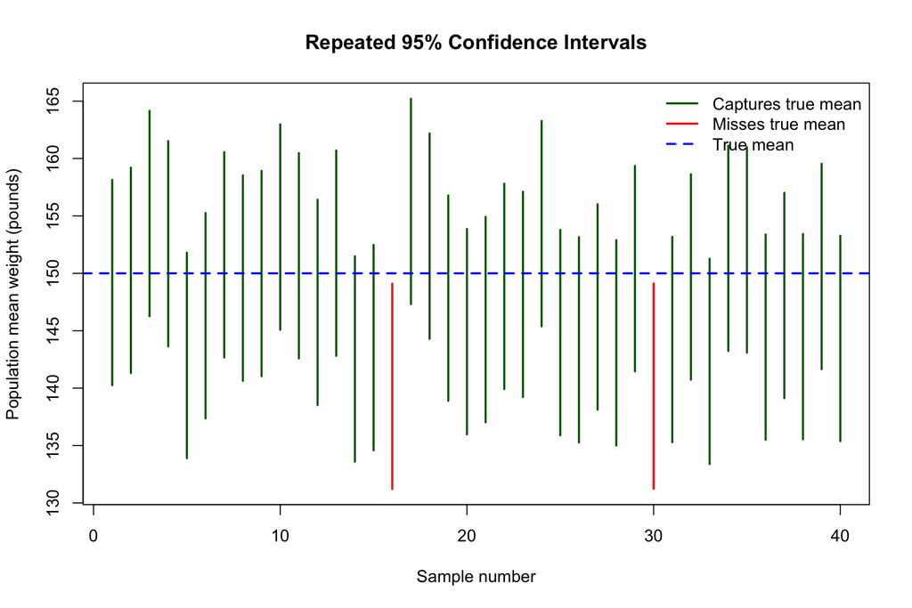

Forty simulated 95% confidence intervals

```r
plot(
  1:n_samples, sample_means,
  type = "n",
  ylim = range(c(lower, upper, mu_true)),
  xlab = "Sample number",
  ylab = "Population mean weight (pounds)",
  main = "Repeated 95% Confidence Intervals"
)

# Draw each confidence interval
for (i in 1:n_samples) {

  segments(
    x0 = i,
    y0 = lower[i],
    x1 = i,
    y1 = upper[i],
    col = ifelse(captured[i], "darkgreen", "red"),
    lwd = 2
  )
}

# The true population mean
abline(h = mu_true, col = "blue", lwd = 2, lty = 2)

legend(
  "topright",
  legend = c("Captures true mean", "Misses true mean", "True mean"),
  col = c("darkgreen", "red", "blue"),
  lwd = 2,
  lty = c(1, 1, 2),
  bty = "n"
)
```

The blue horizontal line represents the fixed population mean.

Green intervals capture the population mean, whereas red intervals miss it.

**Important:** Exactly 95% of the intervals do not have to capture the true mean in every small simulation. The 95% refers to long-run performance.

## Example 5: Coin Toss and Confidence Intervals

Recall the classroom analogy near Wade Lagoon.

Imagine that we repeatedly construct 95% confidence intervals.

Each interval either:

1. Captures the true population mean $\mu$.
2. Fails to capture the true population mean $\mu$.

For a correctly calibrated 95% confidence interval procedure, approximately 95% of intervals should capture $\mu$ over many independent repetitions.

Let us simulate 10,000 samples.

```r
set.seed(312)

mu_true <- 150
sigma <- 25
n <- 30

z_critical <- qnorm(0.975)

# Number of repetitions
N <- 10000

# Simulate whether each CI captures the true mean
captured <- replicate(N, {

  sample_data <- rnorm(
    n,
    mean = mu_true,
    sd = sigma
  )

  xbar <- mean(sample_data)

  ME <- z_critical * sigma / sqrt(n)

  lower <- xbar - ME
  upper <- xbar + ME

  (lower <= mu_true) && (mu_true <= upper)
})

# Proportion of intervals that capture mu
mean(captured)
## [1] 0.9546

# Proportion that do not capture mu
mean(!captured)
## [1] 0.0454
```

The results should be close to

$$P(\text{CI captures }\mu)=0.95$$

and

$$P(\text{CI misses }\mu)=0.05.$$

The outcome for each individual interval is either capture or miss.

The confidence level describes the long-run reliability of the method, not a probability assigned to the fixed parameter after observing the interval.

## Exercise 6: Understanding Confidence Interval Width

Recall the confidence interval for a population mean when $\sigma$ is known:

$$\overline{y}\pm z_{\alpha/2}\frac{\sigma}{\sqrt{n}}.$$

Its total width is

$$\text{Width}
=
2z_{\alpha/2}\frac{\sigma}{\sqrt{n}}.$$

### (a) What makes a confidence interval wider or narrower?

The width depends on three important quantities:

1. Population standard deviation $\sigma$.
2. Sample size $n$.
3. Confidence level $1-\alpha$.

We can define the following function in R:

```r
ci_width <- function(n, sigma, conf_level = 0.95) {

  alpha <- 1 - conf_level

  z_critical <- qnorm(1 - alpha / 2)

  width <- 2 * z_critical * sigma / sqrt(n)

  return(width)
}
```

### Effect of sample size

Keep $\sigma=25$ and the confidence level at 95%.

```r
ci_width(n = 20, sigma = 25)
## [1] 21.91306

ci_width(n = 30, sigma = 25)
## [1] 17.89194

ci_width(n = 100, sigma = 25)
## [1] 9.79982

ci_width(n = 500, sigma = 25)
## [1] 4.382613
```

**Observation:** Increasing sample size decreases the confidence interval width.

### Effect of population standard deviation

Keep $n=30$ and the confidence level at 95%.

```r
ci_width(n = 30, sigma = 10)
## [1] 7.156777

ci_width(n = 30, sigma = 25)
## [1] 17.89194

ci_width(n = 30, sigma = 40)
## [1] 28.62711
```

**Observation:** Larger population standard deviation produces a wider confidence interval.

### Effect of confidence level

Keep $n=30$ and $\sigma=25$.

```r
ci_width(n = 30, sigma = 25, conf_level = 0.90)
## [1] 15.01539

ci_width(n = 30, sigma = 25, conf_level = 0.95)
## [1] 17.89194

ci_width(n = 30, sigma = 25, conf_level = 0.99)
## [1] 23.514
```

**Observation:** Higher confidence levels require wider intervals when the other quantities are fixed.

### (b) What happens with a 100% confidence interval?

For 100% confidence,

$$\alpha=0.$$

Therefore, the critical value would be

$$z_{\alpha/2}=z_0.$$

Let’s examine this using R.

```r
# Critical value for 99% confidence
qnorm(0.995)
## [1] 2.575829

# Critical value for 99.9% confidence
qnorm(0.9995)
## [1] 3.290527

# Critical value corresponding to 100% confidence
qnorm(1)
## [1] Inf
```

R returns `Inf` for `qnorm(1)`.

Therefore, a 100% confidence interval based on this two-sided Normal procedure would have infinite width:

$$(-\infty,\infty).$$

Such an interval would always contain the parameter but would not provide a useful estimate of its location.

## Example 7: Margin of Error and Required Sample Size

For a Z-based confidence interval,

$$ME=z_{\alpha/2}\frac{\sigma}{\sqrt{n}}.$$

### (a) Derive the required sample size

Suppose we want the margin of error to be no greater than $B$.

We require

$$z_{\alpha/2}\frac{\sigma}{\sqrt{n}}\le B.$$

Solving for $n$,

$$n\ge
\left(
\frac{z_{\alpha/2}\sigma}{B}
\right)^2.$$

The required integer sample size is

$$\boxed{
n=
\left\lceil
\left(
\frac{z_{\alpha/2}\sigma}{B}
\right)^2
\right\rceil.
}$$

In R, `ceiling()` rounds up to the next integer when needed.

### (b) Required sample size for CWRU student weights

Recall Example 2:

$$\sigma=25.$$

Suppose we want a 95% confidence interval with a margin of error no greater than 3 pounds.

Given:

$$B=3,\quad \sigma=25,\quad 1-\alpha=0.95.$$

```r
sigma <- 25

B <- 3

conf_level <- 0.95

# Step 1: Find critical Z-value
z_critical <- qnorm(1 - (1 - conf_level) / 2)

# Step 2: Calculate required sample size
n_required <- (z_critical * sigma / B)^2

n_required
## [1] 266.768

# Step 3: Round upward
ceiling(n_required)
## [1] 267
```

We need at least

$$\boxed{n=267\text{ students}.}$$

**Important:** We always round upward because rounding downward could produce a margin of error larger than the desired maximum.

## Example 8: Confidence Intervals at Different Confidence Levels

For a population mean with known $\sigma$,

$$\overline{y}\pm z_{\alpha/2}\frac{\sigma}{\sqrt{n}}.$$

We want to find the critical Z-values for 90%, 95%, and 99% confidence intervals.

### Step 1: Find the critical values

```r
# 90% confidence
z90 <- qnorm(0.95)

# 95% confidence
z95 <- qnorm(0.975)

# 99% confidence
z99 <- qnorm(0.995)

z90
## [1] 1.644854
z95
## [1] 1.959964
z99
## [1] 2.575829
```

The critical values are approximately

$$z_{0.05}=1.645,$$

$$z_{0.025}=1.960,$$

$$z_{0.005}=2.576.$$

### Step 2: Construct the intervals

The general expressions are

$$\text{90% CI: }
\overline{y}\pm1.645\frac{\sigma}{\sqrt{n}},$$

$$\text{95% CI: }
\overline{y}\pm1.960\frac{\sigma}{\sqrt{n}},$$

$$\text{99% CI: }
\overline{y}\pm2.576\frac{\sigma}{\sqrt{n}}.$$

For a numerical illustration, we can reuse the CWRU student-weight information from Example 2:

$$\overline{y}=150,\quad\sigma=25,\quad n=30.$$

```r
xbar <- 150
sigma <- 25
n <- 30

# Construct confidence intervals
ci_mean_z(xbar, sigma, n, conf_level = 0.90)
##    lower    upper
## 142.4923 157.5077

ci_mean_z(xbar, sigma, n, conf_level = 0.95)
##   lower   upper
## 141.054 158.946

ci_mean_z(xbar, sigma, n, conf_level = 0.99)
##   lower   upper
## 138.243 161.757
```

**Question:** Which confidence interval is the widest?

**Answer:** The 99% confidence interval.

A higher confidence level requires a larger critical value, resulting in a larger margin of error.

## Example 9: Confidence Interval for $\mu$ When $\sigma$ Is Unknown

Suppose $\mu$ represents the population mean cholesterol level among 70-year-old American men.

We are given:

- $n=19$
- $\overline{y}=44.2$
- Sample standard deviation $s=3.8$
- Population standard deviation $\sigma$ is unknown.
- Confidence level: 90%

Because the sample size is small, we assume the population distribution is normal.

When $\sigma$ is unknown, we use a t-based confidence interval:

$$\boxed{
\overline{y}\pm
t_{\alpha/2,n-1}\frac{s}{\sqrt{n}}.
}$$

### Step 1: Find the degrees of freedom

$$df=n-1=18.$$

```r
n <- 19
xbar <- 44.2
s <- 3.8
conf_level <- 0.90

df <- n - 1

df
## [1] 18
```

### Step 2: Find the critical t-value

For a 90% confidence interval,

$$\alpha=0.10,\qquad\alpha/2=0.05.$$

We need

$$t_{0.05,18}.$$

Use `qt()`:

```r
alpha <- 1 - conf_level

t_critical <- qt(1 - alpha / 2, df = 18)

t_critical
## [1] 1.734064
```

The critical value is approximately

$$t_{0.05,18}=1.734.$$

### Step 3: Calculate standard error and margin of error

```r
SE <- s / sqrt(n)

ME <- t_critical * SE

SE
## [1] 0.8717798
ME
## [1] 1.511722
```

### Step 4: Construct the confidence interval

```r
lower <- xbar - ME
upper <- xbar + ME

round(c(lower = lower, upper = upper), 3)
##  lower  upper
## 42.688 45.712
```

The 90% confidence interval is approximately

$$\boxed{(42.688,\ 45.712)}.$$

**Interpretation:** Based on the sample, we are 90% confident that the true population mean cholesterol level among 70-year-old American men lies between approximately 42.688 and 45.712.

### Define a reusable t-confidence interval function

```r
ci_mean_t <- function(xbar, s, n, conf_level = 0.95) {

  alpha <- 1 - conf_level

  df <- n - 1

  t_critical <- qt(1 - alpha / 2, df = df)

  SE <- s / sqrt(n)

  ME <- t_critical * SE

  lower <- xbar - ME
  upper <- xbar + ME

  return(c(lower = lower, upper = upper))
}
```

We can now obtain the same result with one command:

```r
ci_mean_t(
  xbar = 44.2,
  s = 3.8,
  n = 19,
  conf_level = 0.90
)
##    lower    upper
## 42.68828 45.71172
```

**Remember:**

- Use `qnorm()` to find Z critical values.
- Use `qt()` to find t critical values.
- The t-distribution requires degrees of freedom.

## Example 10: Reverse-Engineering a Confidence Interval

Suppose we know that

- $n=16$
- $\sigma$ is unknown.
- An 80% confidence interval for $\mu$ is $(48,54)$.

We want to determine the sample mean $\overline{y}$ and sample standard deviation $s$.

### Step 1: Find the sample mean

For a symmetric t-confidence interval,

$$\overline{y}=\frac{L+U}{2}.$$

```r
lower <- 48
upper <- 54

xbar <- (lower + upper) / 2

xbar
## [1] 51
```

Therefore,

$$\boxed{\overline{y}=51}.$$

### Step 2: Find the margin of error

$$ME=\frac{U-L}{2}.$$

```r
ME <- (upper - lower) / 2

ME
## [1] 3
```

Thus,

$$ME=3.$$

### Step 3: Find the critical t-value

For an 80% confidence interval,

$$\alpha=0.20,\qquad df=16-1=15.$$

```r
n <- 16
conf_level <- 0.80

alpha <- 1 - conf_level

df <- n - 1

t_critical <- qt(1 - alpha / 2, df = df)

t_critical
## [1] 1.340606
```

We obtain approximately

$$t_{0.10,15}=1.341.$$

### Step 4: Solve for the sample standard deviation

Recall

$$ME=t_{\alpha/2,n-1}\frac{s}{\sqrt{n}}.$$

Rearranging,

$$s=\frac{ME\sqrt{n}}{t_{\alpha/2,n-1}}.$$

```r
s <- ME * sqrt(n) / t_critical

s
## [1] 8.951178
```

The sample standard deviation is approximately

$$\boxed{s=8.951}.$$

The handwritten solution may differ slightly because the t-value was rounded to 1.341 before calculating $s$.

### Step 5: Verify our result

Use the function from Example 9.

```r
ci_mean_t(
  xbar = 51,
  s = s,
  n = 16,
  conf_level = 0.80
)
## lower upper
##    48    54
```

The result should reproduce the original interval:

$$(48,54).$$

## Example 11: Finding a t Critical Value When $df=74$

Suppose

$$n=75$$

and the population standard deviation is unknown.

We want to construct a 95% confidence interval for $\mu$.

### Step 1: Find the degrees of freedom

```r
n <- 75

df <- n - 1

df
## [1] 74
```

We have

$$df=74.$$

### Step 2: Find the critical t-value

In our printed t-table, $df=74$ may not be listed.

In class, we used the closest available smaller degrees of freedom, $df=70$, to approximate the critical value.

Using R, we can obtain the exact critical value for $df=74$.

```r
# Exact critical value using R
qt(0.975, df = 74)
## [1] 1.992543

# Approximate value from the printed table using df = 70
qt(0.975, df = 70)
## [1] 1.994437
```

R gives approximately

$$t_{0.025,74}=1.993.$$

The printed-table approximation using $df=70$ is approximately 1.994.

**Advantage of R:** We do not need to choose a nearby degrees-of-freedom row. R calculates the appropriate t critical value directly.

The confidence interval has the form

$$\boxed{
\overline{y}\pm1.993\frac{s}{\sqrt{75}}.
}$$

Since this example does not provide a numerical sample mean or sample standard deviation, we cannot calculate the numerical endpoints.

When those values are available, we can use `ci_mean_t()` with $n=75$.

## Example 12: Confidence Interval for a Population Proportion

A sample of 100 one-gallon milk jugs is inspected.

Of these, 80 jugs contain at least one gallon of milk.

Let $p$ denote the true population proportion of jugs containing at least one gallon.

We are given

$$n=100,\qquad X=80.$$

### (a) Estimate the population proportion

The sample proportion is

$$\widehat{p}=\frac{X}{n}.$$

```r
n <- 100

X <- 80

phat <- X / n

phat
## [1] 0.8
```

Therefore,

$$\boxed{\widehat{p}=0.80}.$$

The estimated successful-fill proportion is 80%.

### (b) Construct a 95% confidence interval for $p$

We use the approximate confidence interval

$$\boxed{
\widehat{p}\pm
z_{\alpha/2}
\sqrt{\frac{\widehat{p}(1-\widehat{p})}{n}}.
}$$

#### Step 1: Check the normal approximation conditions

For the method discussed in class, we check that

$$n\widehat{p}\ge15$$

and

$$n(1-\widehat{p})\ge15.$$

```r
# Number of observed successes
n * phat
## [1] 80

# Number of observed failures
n * (1 - phat)
## [1] 20

# Check both conditions
n * phat >= 15
## [1] TRUE

n * (1 - phat) >= 15
## [1] TRUE
```

Both conditions are satisfied:

$$80\ge15,\qquad20\ge15.$$

#### Step 2: Find the critical Z-value

```r
conf_level <- 0.95

alpha <- 1 - conf_level

z_critical <- qnorm(1 - alpha / 2)

z_critical
## [1] 1.959964
```

#### Step 3: Calculate the standard error

```r
SE <- sqrt(phat * (1 - phat) / n)

SE
## [1] 0.04
```

#### Step 4: Calculate the margin of error

```r
ME <- z_critical * SE

ME
## [1] 0.07839856
```

#### Step 5: Construct the confidence interval

```r
lower <- phat - ME
upper <- phat + ME

round(c(lower = lower, upper = upper), 4)
##  lower  upper
## 0.7216 0.8784
```

The approximate 95% confidence interval is

$$\boxed{(0.7216,\ 0.8784)}.$$

**Interpretation:** Based on the sample, we are 95% confident that the population proportion of milk jugs containing at least one gallon lies between approximately 72.16% and 87.84%.

### Reusable R function for a proportion confidence interval

```r
# Wald confidence interval for a population proportion
# This is the Normal-approximation method from our handout.

ci_proportion <- function(X, n, conf_level = 0.95) {

  phat <- X / n

  alpha <- 1 - conf_level

  z_critical <- qnorm(1 - alpha / 2)

  SE <- sqrt(phat * (1 - phat) / n)

  ME <- z_critical * SE

  lower <- phat - ME
  upper <- phat + ME

  return(c(lower = lower, upper = upper))
}
```

Check the result:

```r
ci_proportion(
  X = 80,
  n = 100,
  conf_level = 0.95
)
##     lower     upper
## 0.7216014 0.8783986
```

*Note:* This is the Wald (Normal-approximation) interval used in the handout. Other methods are available for estimating a proportion, and their results may differ.

### (c) What happens if the sample size increases?

Suppose we observe 800 successfully filled jugs out of 1,000.

The sample proportion remains

$$\widehat{p}=\frac{800}{1000}=0.80.$$

We will compare the confidence interval widths.

```r
# Original sample: 80 successes out of 100
CI_100 <- ci_proportion(
  X = 80,
  n = 100,
  conf_level = 0.95
)

# Larger sample: 800 successes out of 1000
CI_1000 <- ci_proportion(
  X = 800,
  n = 1000,
  conf_level = 0.95
)

# Display both intervals
round(CI_100, 4)
##  lower  upper
## 0.7216 0.8784

round(CI_1000, 4)
##  lower  upper
## 0.7752 0.8248

# Compare interval widths
width_100 <- CI_100[2] - CI_100[1]

width_1000 <- CI_1000[2] - CI_1000[1]

width_100
##     upper
## 0.1567971
width_1000
##     upper
## 0.0495836
```

**Observation:** Even though the sample proportion remains 0.80, increasing the sample size makes the interval narrower.

Larger samples generally provide more precise estimates.

### (d) Can we conclude that a majority of jugs are successfully filled?

Recall the 95% confidence interval:

$$(0.7216,\ 0.8784).$$

We want to determine whether the data support the claim

$$p>0.50.$$

Since the entire confidence interval lies above 0.50, the interval supports the conclusion that more than half of all jugs contain at least one gallon.

We can check this in R:

```r
CI <- ci_proportion(
  X = 80,
  n = 100,
  conf_level = 0.95
)

# Is the entire confidence interval above 0.50?
CI[1] > 0.50
## lower
##  TRUE
```

R returns `TRUE`.

Therefore, the data provide sufficient evidence, using the confidence-interval approach discussed in class, that the majority of jugs contain at least one gallon.

This does not mean that every jug is successfully filled.

### (e) Required sample size for a 99% confidence interval

Suppose we want a 99% confidence interval for $p$ with margin of error no greater than

$$B=0.01.$$

#### Case 1: A prior estimate of $p$ is available

Use

$$\widehat{p}=0.80.$$

The required sample size is

$$n=
\left\lceil
\widehat{p}(1-\widehat{p})
\left(\frac{z_{\alpha/2}}{B}\right)^2
\right\rceil.$$

```r
phat <- 0.80

conf_level <- 0.99

B <- 0.01

# Find the critical Z-value
z_critical <- qnorm(1 - (1 - conf_level) / 2)

z_critical
## [1] 2.575829

# Calculate required sample size
n_required <- phat * (1 - phat) * (z_critical / B)^2

n_required
## [1] 10615.83

# Round upward
ceiling(n_required)
## [1] 10616
```

Using the full R critical value, the required sample size is

$$\boxed{n=10616}.$$

**Why is this slightly different from the handwritten answer?**

In the handout, we rounded the critical value to

$$z_{0.005}=2.576.$$

If we use this rounded value in R:

```r
# Using the Z-value rounded as in our printed table

z_table <- 2.576

ceiling(0.80 * 0.20 * (z_table / 0.01)^2)
## [1] 10618
```

We obtain

$$n=10618.$$

Both computations follow the same formula. The difference is due to rounding the critical value.

### (f) Required sample size when no prior estimate is available

If we do not have an estimate of the population proportion, we use

$$\widehat{p}=0.50.$$

This is the conservative choice because

$$p(1-p)\le0.25.$$

The sample-size formula is

$$n=
\left\lceil
0.25\left(\frac{z_{\alpha/2}}{B}\right)^2
\right\rceil.$$

Using R:

```r
phat <- 0.50

conf_level <- 0.99

B <- 0.01

z_critical <- qnorm(1 - (1 - conf_level) / 2)

n_required <- phat * (1 - phat) * (z_critical / B)^2

n_required
## [1] 16587.24

ceiling(n_required)
## [1] 16588
```

Using the full R critical value, we obtain

$$\boxed{n=16588}.$$

Using the rounded value from the printed Z-table:

```r
ceiling(0.25 * (2.576 / 0.01)^2)
## [1] 16590
```

we obtain

$$n=16590.$$

**Observation:** When no prior estimate is available, the conservative sample-size calculation requires a larger sample.

## Making Decisions Using Confidence Intervals for a Proportion

A confidence interval can help us evaluate a claim about the population proportion.

For example, suppose we are interested in whether

$$p>0.50.$$

Consider three possible situations.

### Situation 1: The entire confidence interval is above 0.50

Example:

$$(0.60,\ 0.80).$$

The data support the conclusion that $p>0.50$.

### Situation 2: The entire confidence interval is below 0.50

Example:

$$(0.30,\ 0.41).$$

The data support the conclusion that $p<0.50$.

### Situation 3: The confidence interval contains 0.50

Example:

$$(0.45,\ 0.65).$$

We cannot conclude from this interval alone whether the population proportion is above or below 0.50.

### Checking the three situations using R

```r
# Confidence interval 1
CI1 <- c(0.60, 0.80)

# Confidence interval 2
CI2 <- c(0.30, 0.41)

# Confidence interval 3
CI3 <- c(0.45, 0.65)

# Case 1: Entire interval above 0.50
CI1[1] > 0.50
## [1] TRUE

# Case 2: Entire interval below 0.50
CI2[2] < 0.50
## [1] TRUE

# Case 3: Interval contains 0.50
CI3[1] <= 0.50 && CI3[2] >= 0.50
## [1] TRUE
```

**Important:** These conclusions are based on two-sided confidence intervals. The connection with hypothesis testing will become clearer when we discuss significance levels and rejection regions.

## Quick Reference: Z and t Critical Values in R

The following commands are particularly useful when constructing confidence intervals.

### Z critical values

```r
# 90% confidence
qnorm(0.95)
## [1] 1.644854

# 95% confidence
qnorm(0.975)
## [1] 1.959964

# 99% confidence
qnorm(0.995)
## [1] 2.575829
```

### t critical values

```r
# 90% confidence interval, df = 18
qt(0.95, df = 18)
## [1] 1.734064

# 95% confidence interval, df = 15
qt(0.975, df = 15)
## [1] 2.13145

# 95% confidence interval, df = 74
qt(0.975, df = 74)
## [1] 1.992543

# 99% confidence interval, df = 20
qt(0.995, df = 20)
## [1] 2.84534
```

### Verify probability between critical values

```r
# 95% central probability for standard Normal
z <- qnorm(0.975)

pnorm(z) - pnorm(-z)
## [1] 0.95

# 95% central probability for t distribution, df = 18
t <- qt(0.975, df = 18)

pt(t, df = 18) - pt(-t, df = 18)
## [1] 0.95
```

Both central probabilities should equal approximately 0.95.

## Independent Practice Using R

Try the following problems using the R functions from this handout.

**Practice 1: Confidence interval for a mean**

Suppose

$$n=50,\quad\overline{x}=72,\quad\sigma=12.$$

Construct 90%, 95%, and 99% confidence intervals for $\mu$.

```r
# Enter the values and use ci_mean_z()
```

**Practice 2: Confidence interval using t**

Suppose

$$n=25,\quad\overline{x}=40,\quad s=8.$$

Construct a 95% confidence interval for $\mu$ assuming the population is normally distributed.

```r
# Use qt() or ci_mean_t()
```

**Practice 3: Confidence interval for a proportion**

Suppose 180 out of 250 randomly selected items satisfy a particular quality requirement.

Estimate $p$ and construct a 95% confidence interval.

```r
# Use ci_proportion()
```

**Practice 4: Required sample size**

Suppose $\sigma=15$, and we want a 99% confidence interval for $\mu$ with a margin of error no greater than 2.

Find the required sample size.

```r
# Use qnorm(), sqrt(), and ceiling() as appropriate
```

**Practice 5: Conceptual question**

Explain why increasing the confidence level from 90% to 99% makes a confidence interval wider when the sample size and standard deviation remain unchanged.

Use R to support your explanation.

```r
# Compare critical values and interval widths
```

## Final Reminders

1. Use **`qnorm()`** for Z critical values and **`qt()`** for t critical values.
2. For a mean, use a Z-based interval when the population standard deviation is known and the normal sampling approximation is appropriate.
3. When $\sigma$ is unknown, use the sample standard deviation $s$ and a t-based interval under appropriate assumptions.
4. For a t critical value, remember that the degrees of freedom are $n-1$.
5. For a sample proportion, check the conditions for the Normal approximation before using the corresponding confidence interval.
6. A confidence interval estimates an unknown **population parameter**, not the range of individual observations.
7. Increasing the confidence level makes the interval wider, while increasing the sample size generally makes it narrower.
8. Use **`ceiling()`** when computing a required sample size.
9. Differences between R and printed-table results may occur because R uses more precise critical values.
10. Understanding which statistical method applies, its assumptions, and how to interpret the result is just as important as obtaining the numerical answer using R.

# Unit 08: Hypothesis Testing in R

In this unit, we will learn how to conduct hypothesis tests using R.

Previously, we used printed Z-, t-, and chi-square tables to find critical values and place bounds on p-values. R allows us to calculate these quantities directly, without relying on printed tables or rounding to the nearest table entry.

Our main objectives are to:

1. Calculate Type I and Type II error probabilities.
2. Find rejection regions using critical values.
3. Calculate Z-, t-, and chi-square test statistics.
4. Calculate exact numerical p-values using R’s distribution functions.
5. Compare p-values with significance levels.
6. Make appropriate statistical decisions and interpret them in context.

## Important R Functions

The following base R functions will be useful:

- `pnorm()` computes probabilities under a Normal distribution.
- `qnorm()` finds Normal critical values.
- `pt()` computes probabilities under a t-distribution.
- `qt()` finds t critical values.
- `pchisq()` computes probabilities under a chi-square distribution.
- `qchisq()` finds chi-square critical values.
- `dbinom()` computes binomial probabilities.
- `sqrt()` calculates square roots.
- `abs()` calculates absolute values.

**Remember:**

Functions beginning with `p` calculate probabilities, while functions beginning with `q` calculate critical values or percentiles.

For example:

```r
# P(Z < 1.96)
pnorm(1.96)
## [1] 0.9750021

# P(Z > 1.96)
pnorm(1.96, lower.tail = FALSE)
## [1] 0.0249979

# Find z such that P(Z < z) = 0.975
qnorm(0.975)
## [1] 1.959964
```

## A Quick Review of Hypothesis Testing

A statistical hypothesis test begins with two competing hypotheses:

$$H_0:\text{Null hypothesis}$$

versus

$$H_a:\text{Alternative hypothesis}.$$

We temporarily assume that $H_0$ is true and examine whether the sample provides sufficient evidence against it.

### Significance level

The significance level is denoted by $\alpha$.

$$\alpha=P(\text{Reject }H_0\mid H_0\text{ is true}).$$

For a test with an exact Type I error probability equal to its chosen significance level, this is the probability of a Type I error.

Common significance levels are

$$\alpha=0.10,\quad 0.05,\quad 0.01.$$

### Type I and Type II errors

A **Type I error** occurs when we reject a true null hypothesis.

A **Type II error** occurs when we fail to reject a false null hypothesis.

The probability of a Type II error is denoted by $\beta$.

$$\beta=P(\text{Fail to reject }H_0\mid H_0\text{ is false}).$$

The power of a test, at a specified alternative, is

$$\text{Power}=1-\beta.$$

We will examine these concepts in Example 1.

## Example 1: Basket A versus Basket B

Three balls are randomly drawn, **with replacement**, from either Basket A or Basket B.

We do not know which basket is being used.

Basket A contains:

- 9 red balls
- 1 green ball

Basket B contains:

- 1 red ball
- 4 green balls

We want to test

$$H_0:\text{The balls come from Basket A}$$

versus

$$H_a:\text{The balls come from Basket B}.$$

### Decision rule

Reject $H_0$ if all three selected balls are green.

Otherwise, fail to reject $H_0$.

Since the draws are made with replacement, the individual draws are independent.

### Part (a): Probability of a Type I error

A Type I error occurs when we reject $H_0$, even though the balls actually come from Basket A.

Under Basket A,

$$P(\text{Green})=\frac{1}{10}=0.10.$$

The decision rule rejects $H_0$ when the observed sequence is GGG.

Therefore,

$$\alpha=P(GGG\mid\text{Basket A})
=(0.10)^3.$$

Using R:

```r
# Basket A

p_green_A <- 1 / 10

# Probability of three green balls
alpha_basket <- p_green_A^3

alpha_basket
## [1] 0.001
```

We obtain

$$\boxed{\alpha=0.001}.$$

Thus, the probability of making a Type I error is 0.001.

We can also calculate the same probability using the binomial distribution.

```r
# Probability of exactly three green balls
# in three independent draws from Basket A

dbinom(
  x = 3,
  size = 3,
  prob = 0.10
)
## [1] 0.001
```

The result is again 0.001.

### Part (b): Probability of a Type II error

A Type II error occurs when the balls come from Basket B but we fail to reject $H_0$.

Under Basket B,

$$P(\text{Green})=\frac45=0.80.$$

We fail to reject $H_0$ whenever the three draws are **not all green**.

Therefore,

$$\beta
=1-P(GGG\mid\text{Basket B})
=1-(0.80)^3.$$

Using R:

```r
# Basket B

p_green_B <- 4 / 5

# Probability of failing to reject H0
beta_basket <- 1 - p_green_B^3

beta_basket
## [1] 0.488
```

We obtain

$$\boxed{\beta=0.488}.$$

Alternatively, we can use `dbinom()`:

```r
# Probability of NOT observing three green balls

1 - dbinom(
  x = 3,
  size = 3,
  prob = 0.80
)
## [1] 0.488
```

### Part (c): Find the power of the test

Power is the probability of correctly rejecting $H_0$ when Basket B is used.

$$\text{Power}=1-\beta.$$

Using R:

```r
power_basket <- 1 - beta_basket

power_basket
## [1] 0.512
```

We obtain

$$\boxed{\text{Power}=0.512}.$$

In other words, when Basket B is actually used, our decision rule correctly identifies it approximately 51.2% of the time.

### Part (d): What if we never reject $H_0$?

Suppose we change our decision rule so that we never reject $H_0$, regardless of which balls are observed.

Then,

$$\alpha=0$$

because we never reject a true null hypothesis.

However,

$$\beta=1$$

because we also never reject $H_0$ when Basket B is used.

```r
alpha_never_reject <- 0

beta_never_reject <- 1

power_never_reject <- 1 - beta_never_reject

alpha_never_reject
## [1] 0
beta_never_reject
## [1] 1
power_never_reject
## [1] 0
```

**Important observation:**

We can force the Type I error probability to zero by never rejecting $H_0$, but then the Type II error probability becomes one.

This demonstrates why controlling Type I error alone is not sufficient for designing a useful test.

## Example 2: Purchasing Shipments of Iron Ore Pellets

A company purchases shipments of iron ore pellets.

Let

$$\mu=\text{population mean shipment weight}.$$

The supplier claims that the average shipment weighs 80 pounds.

We suspect that the shipments may be underweight.

The population standard deviation is known:

$$\sigma=10\text{ pounds}.$$

### Step 1: State the hypotheses

Since we suspect that the average shipment weight is less than 80 pounds, we use a left-tailed test:

$$H_0:\mu=80$$

versus

$$H_a:\mu<80.$$

Suppose we randomly select

$$n=30$$

shipments and obtain a sample mean of

$$\overline{x}=76.$$

We use

$$\alpha=0.05.$$

### Step 2: Calculate the Z-test statistic

Since $\sigma$ is known, we use

$$Z=\frac{\overline{X}-\mu_0}{\sigma/\sqrt{n}}.$$

Under $H_0$, the sampling distribution is approximately standard Normal, assuming the observations are independent and the normal approximation is appropriate.

Enter the values into R.

```r
# Given information

mu0_iron <- 80
sigma_iron <- 10
n_iron <- 30
xbar_iron <- 76

alpha_iron <- 0.05

# Calculate the standard error
SE_iron <- sigma_iron / sqrt(n_iron)

# Calculate the Z-test statistic
z_iron <- (xbar_iron - mu0_iron) / SE_iron

z_iron
## [1] -2.19089
```

We obtain approximately

$$\boxed{z=-2.191}.$$

### Step 3: Find the rejection region

For a left-tailed test,

$$\text{Reject }H_0\text{ if }Z<z_\alpha.$$

With $\alpha=0.05$,

$$z_\alpha=-1.645.$$

Using R:

```r
# Critical value for a left-tailed test

z_critical_iron <- qnorm(alpha_iron)

z_critical_iron
## [1] -1.644854
```

The rejection region is

$$\boxed{Z<-1.645}.$$

### Step 4: Make the decision using the rejection region

Our observed statistic is

$$z=-2.191.$$

Since

$$-2.191<-1.645,$$

we reject $H_0$.

We can ask R to make this comparison directly:

```r
# Does the observed test statistic fall
# inside the rejection region?

z_iron < z_critical_iron
## [1] TRUE
```

R returns `TRUE`.

Therefore, we reject $H_0$ at the 5% significance level.

### Step 5: Calculate the p-value

For a left-tailed test, the p-value is

$$P(Z\le z_{\text{observed}}).$$

Use `pnorm()`.

```r
# Left-tailed p-value

pvalue_iron <- pnorm(z_iron)

pvalue_iron
## [1] 0.01422987
```

The p-value is approximately

$$\boxed{p=0.0142}.$$

Since

$$0.0142<0.05,$$

we reject $H_0$.

Check in R:

```r
pvalue_iron < alpha_iron
## [1] TRUE
```

### Conclusion

At the 5% significance level, there is sufficient statistical evidence that the population mean shipment weight is less than 80 pounds.

This supports the concern that the shipments may be underweight.

### Optional: Visualize the rejection region

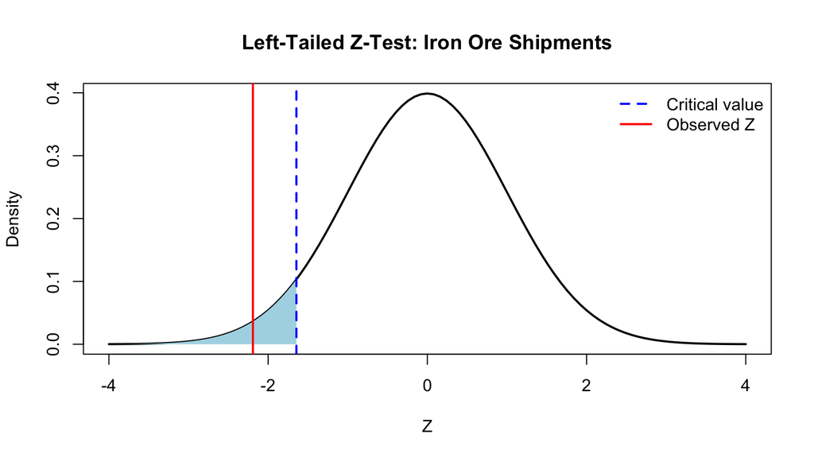

```r
curve(
  dnorm(x),
  from = -4,
  to = 4,
  lwd = 2,
  xlab = "Z",
  ylab = "Density",
  main = "Left-Tailed Z-Test: Iron Ore Shipments"
)

# Shade the rejection region
x_reject <- seq(-4, z_critical_iron, length.out = 300)

polygon(
  c(-4, x_reject, z_critical_iron),
  c(0, dnorm(x_reject), 0),
  col = "lightblue",
  border = NA
)

# Critical value
abline(
  v = z_critical_iron,
  col = "blue",
  lwd = 2,
  lty = 2
)

# Observed test statistic
abline(
  v = z_iron,
  col = "red",
  lwd = 2
)

legend(
  "topright",
  legend = c("Critical value", "Observed Z"),
  col = c("blue", "red"),
  lty = c(2, 1),
  lwd = 2,
  bty = "n"
)
```

## Choosing the Correct Alternative Hypothesis

Recall that the direction of the alternative hypothesis determines the type of test.

### Left-tailed test

$$H_a:\mu<\mu_0.$$

The p-value is

```r
# For a left-tailed Z-test

pnorm(-1.50)
## [1] 0.0668072
```

### Right-tailed test

$$H_a:\mu>\mu_0.$$

The p-value is

```r
# For a right-tailed Z-test

pnorm(1.50, lower.tail = FALSE)
## [1] 0.0668072
```

### Two-tailed test

$$H_a:\mu\ne\mu_0.$$

For a symmetric standard Normal distribution, the p-value is

$$2P(Z>|z_{\text{observed}}|).$$

```r
# For a two-tailed Z-test

z_observed <- 1.50

2 * pnorm(abs(z_observed), lower.tail = FALSE)
## [1] 0.1336144
```

**Important:** Do not automatically multiply every p-value by two. We multiply the one-tail probability by two for a two-sided test because the Normal distribution is symmetric.

## Classroom Example A: Two-Tailed Z-Test

Suppose

$$H_0:\mu=50$$

versus

$$H_a:\mu\ne50.$$

We are given

$$\alpha=0.01,\quad
\overline{x}=53,\quad
n=64,\quad
\sigma=16.$$

Since the population standard deviation is known, we use the Z-test.

### Step 1: Calculate the Z-test statistic

$$Z=\frac{\overline{X}-\mu_0}{\sigma/\sqrt{n}}.$$

```r
mu0_A <- 50
xbar_A <- 53
n_A <- 64
sigma_A <- 16

alpha_A <- 0.01

z_A <- (xbar_A - mu0_A) /
  (sigma_A / sqrt(n_A))

z_A
## [1] 1.5
```

We obtain

$$\boxed{z=1.50}.$$

### Step 2: Find the rejection region

Since this is a two-tailed test with $\alpha=0.01$, each tail contains probability 0.005.

The critical value is

$$z_{\alpha/2}=2.576.$$

Use R:

```r
z_critical_A <- qnorm(1 - alpha_A / 2)

z_critical_A
## [1] 2.575829

# Negative critical value
-z_critical_A
## [1] -2.575829
```

The rejection region is

$$Z<-2.576
\quad\text{or}\quad
Z>2.576.$$

Equivalently,

$$\boxed{|Z|>2.576}.$$

### Step 3: Make the decision

```r
abs(z_A) > z_critical_A
## [1] FALSE
```

R returns `FALSE`.

We fail to reject $H_0$.

### Step 4: Calculate the p-value

For a two-tailed Z-test,

$$p=2P(Z>|z_{\text{observed}}|).$$

```r
pvalue_A <- 2 * pnorm(
  abs(z_A),
  lower.tail = FALSE
)

pvalue_A
## [1] 0.1336144
```

We obtain

$$\boxed{p\approx0.1336}.$$

Since

$$0.1336>0.01,$$

we fail to reject $H_0$.

### Conclusion

At the 1% significance level, there is insufficient evidence to conclude that the population mean differs from 50.

## Classroom Example B: Right-Tailed Z-Test

Suppose

$$H_0:\mu=70$$

versus

$$H_a:\mu>70.$$

We are given

$$\alpha=0.09,\quad
\overline{x}=74,\quad
n=36,\quad
\sigma=12.$$

### Step 1: Calculate the test statistic

```r
mu0_B <- 70
xbar_B <- 74
sigma_B <- 12
n_B <- 36

alpha_B <- 0.09

z_B <- (xbar_B - mu0_B) /
  (sigma_B / sqrt(n_B))

z_B
## [1] 2
```

We obtain

$$\boxed{z=2}.$$

### Step 2: Find the rejection region

For a right-tailed test,

$$\text{Reject }H_0\text{ if }Z>z_\alpha.$$

Use `qnorm()`:

```r
z_critical_B <- qnorm(1 - alpha_B)

z_critical_B
## [1] 1.340755
```

We obtain approximately

$$z_\alpha=1.341.$$

Thus, the rejection region is

$$Z>1.341.$$

Since

$$2>1.341,$$

we reject $H_0$.

### Step 3: Calculate the p-value

For a right-tailed test,

$$p=P(Z>2).$$

```r
pvalue_B <- pnorm(
  z_B,
  lower.tail = FALSE
)

pvalue_B
## [1] 0.02275013
```

We obtain

$$\boxed{p\approx0.0228}.$$

### Step 4: Compare the same p-value with different significance levels

One advantage of reporting a p-value is that we can assess statistical significance at different significance levels.

```r
# Compare the p-value with three significance levels

alpha_levels_B <- c(0.09, 0.05, 0.01)

data.frame(
  significance_level = alpha_levels_B,
  p_value = rep(pvalue_B, length(alpha_levels_B)),
  reject_H0 = pvalue_B < alpha_levels_B
)
##   significance_level    p_value reject_H0
## 1               0.09 0.02275013      TRUE
## 2               0.05 0.02275013      TRUE
## 3               0.01 0.02275013     FALSE
```

The results show that:

- At $\alpha=0.09$, reject $H_0$.
- At $\alpha=0.05$, reject $H_0$.
- At $\alpha=0.01$, fail to reject $H_0$.

**Important observation:** The p-value does not change when we choose a different significance level. The significance decision may change because we compare the same p-value against a different threshold.

## Hypothesis Testing for a Population Mean When $\sigma$ Is Unknown

When the population standard deviation is unknown, we generally use a **one-sample t-test**.

The test statistic is

$$\boxed{
T=\frac{\overline{X}-\mu_0}{S/\sqrt{n}}.
}$$

For independent observations from a Normal population, under $H_0$,

$$T\sim t_{n-1}.$$

The degrees of freedom are

$$df=n-1.$$

In R, the relevant functions are:

- `qt()` for t critical values.
- `pt()` for t probabilities and p-values.

For sufficiently large samples, t-based procedures can also be appropriate approximately under suitable conditions.

## Classroom Example: Cholesterol Levels

Recall the cholesterol example from Unit 07.

Let

$$\mu=\text{population mean cholesterol level among 70-year-old American men}.$$

We want to test

$$H_0:\mu=45.5$$

versus

$$H_a:\mu<45.5.$$

We are given

$$n=19,\quad
\overline{x}=44.2,\quad
s=3.8.$$

The population standard deviation is unknown.

Assume the population distribution is Normal.

We use

$$\alpha=0.05.$$

### Step 1: Calculate the t-test statistic

```r
mu0_chol <- 45.5

xbar_chol <- 44.2

s_chol <- 3.8

n_chol <- 19

alpha_chol <- 0.05

# Degrees of freedom
df_chol <- n_chol - 1

# Standard error
SE_chol <- s_chol / sqrt(n_chol)

# Observed t-test statistic
t_chol <- (xbar_chol - mu0_chol) / SE_chol

df_chol
## [1] 18
t_chol
## [1] -1.491202
```

We obtain

$$df=18,\qquad t\approx-1.491.$$

### Step 2: Find the rejection region

Since the alternative hypothesis is left-tailed, we reject $H_0$ for sufficiently negative values of $T$.

The critical value is

$$t_{0.05,18}=-1.734.$$

Using R:

```r
t_critical_chol <- qt(
  alpha_chol,
  df = df_chol
)

t_critical_chol
## [1] -1.734064
```

Thus, the rejection region is

$$\boxed{T<-1.734}.$$

### Step 3: Make the decision

The observed t-test statistic is approximately

$$t=-1.491.$$

Since

$$-1.491>-1.734,$$

the statistic does not fall in the rejection region.

Check in R:

```r
t_chol < t_critical_chol
## [1] FALSE
```

We fail to reject $H_0$.

### Step 4: Calculate the p-value

For a left-tailed t-test,

$$p=P(T_{18}\le -1.491).$$

Use `pt()`:

```r
pvalue_chol <- pt(
  t_chol,
  df = df_chol
)

pvalue_chol
## [1] 0.07661283
```

We obtain approximately

$$\boxed{p=0.0766}.$$

Since

$$0.0766>0.05,$$

we fail to reject $H_0$.

### Conclusion

At the 5% significance level, the sample does not provide sufficient evidence to conclude that the population mean cholesterol level is below 45.5.

**Important:** Failing to reject $H_0$ does not prove that the population mean equals 45.5.

## Placing Bounds on p-values Using the t-Distribution

In class, we used a printed t-table to place bounds on p-values.

R allows us to calculate the p-value more precisely.

Let us first revisit the cholesterol example.

We obtained

$$t=-1.491,\qquad df=18.$$

For a left-tailed test, the relevant critical values are approximately

$$t_{0.05,18}=-1.734$$

and

$$t_{0.10,18}=-1.330.$$

Using R:

```r
# Left-tail cutoff corresponding to 0.05
qt(0.05, df = 18)
## [1] -1.734064

# Left-tail cutoff corresponding to 0.10
qt(0.10, df = 18)
## [1] -1.330391
```

Since

$$-1.734<-1.491<-1.330,$$

we conclude that

$$\boxed{0.05<p\text{-value}<0.10}.$$

Using R, the more precise p-value is

```r
pt(t_chol, df = 18)
## [1] 0.07661283
```

which is approximately 0.0766.

The table-based bounds and the direct R calculation are consistent.

## Practice Example: Right-Tailed t-Test

Suppose we have

$$n=26,$$

and our observed test statistic is

$$t=2.1.$$

We are conducting a right-tailed test.

Find bounds on the p-value and then calculate its numerical value using R.

### Step 1: Degrees of freedom

$$df=26-1=25.$$

### Step 2: Identify the relevant critical values

In the printed table, we find approximately

$$t_{0.025,25}=2.060$$

and

$$t_{0.01,25}=2.485.$$

Using R:

```r
df_right_t <- 25

t_right <- 2.1

# Upper-tail probability 0.025
qt(1 - 0.025, df = df_right_t)
## [1] 2.059539

# Upper-tail probability 0.01
qt(1 - 0.01, df = df_right_t)
## [1] 2.485107
```

Because

$$2.060<2.1<2.485,$$

the p-value must satisfy

$$\boxed{0.01<p\text{-value}<0.025}.$$

### Step 3: Calculate the p-value directly

For a right-tailed t-test,

$$p=P(T_{25}>2.1).$$

Use

```r
pvalue_right_t <- pt(
  t_right,
  df = df_right_t,
  lower.tail = FALSE
)

pvalue_right_t
## [1] 0.02299214
```

We obtain

$$\boxed{p\approx0.0230}.$$

This value lies between 0.01 and 0.025, as expected.

## Practice Example: Two-Tailed t-Test

Suppose we have

$$n=21,$$

with an observed test statistic

$$t=2.$$

The alternative hypothesis is two-sided.

### Step 1: Degrees of freedom

$$df=21-1=20.$$

### Step 2: Find the relevant critical values

From the t-table,

$$t_{0.05,20}=1.725$$

and

$$t_{0.025,20}=2.086.$$

Using R:

```r
df_two_t <- 20

t_two <- 2

# Upper-tail probability 0.05
qt(0.95, df = df_two_t)
## [1] 1.724718

# Upper-tail probability 0.025
qt(0.975, df = df_two_t)
## [1] 2.085963
```

Since

$$1.725<2<2.086,$$

the one-tail probability is between 0.025 and 0.05.

Because this is a two-tailed test, we multiply by two.

Therefore,

$$\boxed{0.05<p\text{-value}<0.10}.$$

### Step 3: Calculate the numerical p-value

```r
pvalue_two_t <- 2 * pt(
  abs(t_two),
  df = df_two_t,
  lower.tail = FALSE
)

pvalue_two_t
## [1] 0.05926554
```

We obtain

$$\boxed{p\approx0.0593}.$$

This is consistent with the bounds obtained from the printed t-table.

**Important:** For a two-sided t-test, the factor of two accounts for the probability in both tails of the symmetric t-distribution.

## Example 3: Hypothesis Testing for a Population Proportion

A gambler develops a new strategy for a game.

Historically, the probability of winning the game is 0.49.

The gambler believes the new strategy increases the probability of winning.

He plays the game 80 times and wins 44 games.

Assume the games are independent and that the probability of winning remains constant.

Let

$$p=\text{population probability of winning using the new strategy}.$$

We want to test the new strategy at

$$\alpha=0.05.$$

### Part (a): State the hypotheses

Since the gambler believes the new strategy increases the winning probability, we use a right-tailed test.

$$H_0:p=0.49$$

versus

$$H_a:p>0.49.$$

### Step 1: Calculate the sample proportion

We are given

$$n=80,\quad X=44.$$

The sample proportion is

$$\widehat p=\frac{44}{80}=0.55.$$

In R:

```r
n_gambler <- 80

X_gambler <- 44

p0_gambler <- 0.49

alpha_gambler <- 0.05

phat_gambler <- X_gambler / n_gambler

phat_gambler
## [1] 0.55
```

We obtain

$$\widehat p=0.55.$$

### Step 2: Check the Normal approximation conditions

For a one-proportion Z-test, the standard error under $H_0$ uses the hypothesized proportion $p_0$, not $\widehat p$.

The usual approximation checks are

$$np_0\ge15$$

and

$$n(1-p_0)\ge15.$$

Using R:

```r
# Expected successes under H0
n_gambler * p0_gambler
## [1] 39.2

# Expected failures under H0
n_gambler * (1 - p0_gambler)
## [1] 40.8

# Check the conditions
n_gambler * p0_gambler >= 15
## [1] TRUE

n_gambler * (1 - p0_gambler) >= 15
## [1] TRUE
```

Both conditions are satisfied.

### Step 3: Calculate the test statistic

The one-proportion Z-test statistic is

$$\boxed{
Z=
\frac{\widehat p-p_0}
{\sqrt{p_0(1-p_0)/n}}.
}$$

Using R:

```r
# Standard error under H0
SE_gambler <- sqrt(
  p0_gambler * (1 - p0_gambler) / n_gambler
)

# Z-test statistic
z_gambler <- (phat_gambler - p0_gambler) /
  SE_gambler

z_gambler
## [1] 1.073527
```

We obtain approximately

$$\boxed{z=1.074}.$$

### Step 4: Find the rejection region

Since this is a right-tailed test at $\alpha=0.05$,

$$\text{Reject }H_0\text{ if }Z>1.645.$$

Use R:

```r
z_critical_gambler <- qnorm(1 - alpha_gambler)

z_critical_gambler
## [1] 1.644854
```

Compare:

```r
z_gambler > z_critical_gambler
## [1] FALSE
```

R returns `FALSE`.

We fail to reject $H_0$.

### Step 5: Calculate the p-value

For a right-tailed Z-test,

$$p=P(Z>1.074).$$

Using R:

```r
pvalue_gambler <- pnorm(
  z_gambler,
  lower.tail = FALSE
)

pvalue_gambler
## [1] 0.1415173
```

We obtain approximately

$$\boxed{p=0.1415}.$$

Since

$$0.1415>0.05,$$

we fail to reject $H_0$.

### Conclusion

At the 5% significance level, the results do not provide sufficient statistical evidence that the gambler’s new strategy increases the probability of winning above 0.49.

Although the observed winning proportion was 0.55, the difference is not statistically significant at the chosen level.

### Using the built-in R function `prop.test()`

R also provides the function `prop.test()` for testing a population proportion.

For comparison:

```r
prop.test(
  x = 44,
  n = 80,
  p = 0.49,
  alternative = "greater",
  correct = FALSE
)
##
##  1-sample proportions test without continuity correction
##
## data:  44 out of 80, null probability 0.49
## X-squared = 1.1525, df = 1, p-value = 0.1415
## alternative hypothesis: true p is greater than 0.49
## 95 percent confidence interval:
##  0.4583692 1.0000000
## sample estimates:
##    p
## 0.55
```

We set `correct = FALSE` to remove the continuity correction and make the result agree with the Normal-approximation Z-test used in class.

**Note:** The reported statistic from `prop.test()` is labeled `X-squared`, but the one-sided p-value agrees with the corresponding Z-test in this setting.

## Example 3(b): What if the Gambler Won 55 Out of 100 Games?

Suppose the gambler instead played

$$n=100$$

games and won

$$X=55.$$

The sample proportion is still

$$\widehat p=0.55.$$

Would the p-value increase or decrease?

### Step 1: Calculate the Z-test statistic

```r
n_gambler2 <- 100

X_gambler2 <- 55

phat_gambler2 <- X_gambler2 / n_gambler2

# Same null proportion
p0_gambler2 <- 0.49

SE_gambler2 <- sqrt(
  p0_gambler2 * (1 - p0_gambler2) / n_gambler2
)

z_gambler2 <- (phat_gambler2 - p0_gambler2) /
  SE_gambler2

z_gambler2
## [1] 1.20024
```

We obtain

$$\boxed{z\approx1.200}.$$

### Step 2: Find the p-value

```r
pvalue_gambler2 <- pnorm(
  z_gambler2,
  lower.tail = FALSE
)

pvalue_gambler2
## [1] 0.1150231
```

We obtain approximately

$$\boxed{p=0.1150}.$$

### Step 3: Compare the two experiments

```r
data.frame(
  sample_size = c(80, 100),
  wins = c(44, 55),
  sample_proportion = c(
    phat_gambler,
    phat_gambler2
  ),
  z_statistic = c(
    z_gambler,
    z_gambler2
  ),
  p_value = c(
    pvalue_gambler,
    pvalue_gambler2
  )
)
##   sample_size wins sample_proportion z_statistic   p_value
## 1          80   44              0.55    1.073527 0.1415173
## 2         100   55              0.55    1.200240 0.1150231
```

**Observation:** The sample proportion remains 0.55, but the p-value decreases as the sample size increases.

This happens because a larger sample size reduces the standard error.

However, the new p-value is still greater than 0.05, so we continue to fail to reject $H_0$.

## Example 4: Hypothesis Testing for a Population Variance

A manufacturer produces sticks of dynamite designed to detonate after approximately 25 seconds.

For safety and consistency, the manufacturer wants the variability in detonation times to remain small.

The claimed population variance is

$$\sigma_0^2=0.25\text{ seconds}^2.$$

The manufacturer is concerned that the actual variance may be larger.

Assume the detonation times form an independent random sample from a Normal population.

The sample information is

$$n=20,$$

$$\overline{x}=25\text{ seconds},$$

$$s^2=0.2916\text{ seconds}^2.$$

We will test at

$$\alpha=0.01.$$

### Step 1: State the hypotheses

We want to determine whether the population variance exceeds 0.25.

Therefore,

$$H_0:\sigma^2=0.25$$

versus

$$H_a:\sigma^2>0.25.$$

This is a right-tailed chi-square test.

### Step 2: Calculate the chi-square test statistic

When testing a population variance from a Normal population, the test statistic is

$$\boxed{
\chi^2=
\frac{(n-1)S^2}{\sigma_0^2}.
}$$

Under the null hypothesis,

$$\chi^2\sim\chi^2_{n-1}.$$

Enter the values into R:

```r
n_var <- 20

s2_var <- 0.2916

sigma2_0 <- 0.25

alpha_var <- 0.01

# Degrees of freedom
df_var <- n_var - 1

# Chi-square test statistic
chisq_var <- (n_var - 1) * s2_var / sigma2_0

df_var
## [1] 19
chisq_var
## [1] 22.1616
```

We obtain

$$\boxed{\chi^2=22.1616}.$$

### Step 3: Find the rejection region

For a right-tailed chi-square test at $\alpha=0.01$, reject $H_0$ when

$$\chi^2>\chi^2_{0.01,19}.$$

We use `qchisq()` to find the critical value.

```r
chisq_critical_var <- qchisq(
  1 - alpha_var,
  df = df_var
)

chisq_critical_var
## [1] 36.19087
```

We obtain

$$\boxed{\chi^2_{0.01,19}\approx36.191}.$$

Therefore, the rejection region is

$$\chi^2>36.191.$$

### Step 4: Make the decision

Our observed statistic is approximately

$$\chi^2=22.162.$$

Since

$$22.162<36.191,$$

we fail to reject $H_0$.

Check in R:

```r
chisq_var > chisq_critical_var
## [1] FALSE
```

R returns `FALSE`.

### Step 5: Calculate the p-value

For this right-tailed chi-square test,

$$p=P(\chi^2_{19}>22.1616).$$

We use `pchisq()`.

```r
pvalue_var <- pchisq(
  chisq_var,
  df = df_var,
  lower.tail = FALSE
)

pvalue_var
## [1] 0.2762877
```

We obtain approximately

$$\boxed{p=0.2763}.$$

Since

$$0.2763>0.01,$$

we fail to reject $H_0$.

### Conclusion

At the 1% significance level, there is insufficient statistical evidence that the population variance in detonation times exceeds 0.25 seconds squared.

**Important:** We have not proven that the variance equals 0.25. We have only concluded that the observed sample does not provide sufficient evidence that it is larger.

### Visualizing the chi-square distribution

Unlike the standard Normal and t-distributions, the chi-square distribution is generally right-skewed.

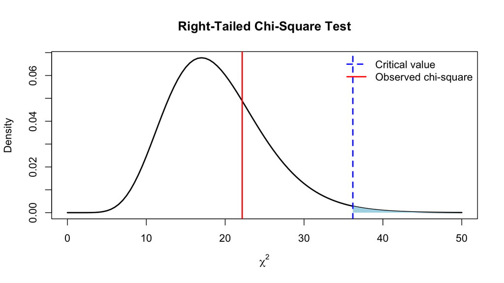

```r
curve(
  dchisq(x, df = df_var),
  from = 0,
  to = 50,
  lwd = 2,
  xlab = expression(chi^2),
  ylab = "Density",
  main = "Right-Tailed Chi-Square Test"
)

# Shade the rejection region
x_reject_chi <- seq(
  chisq_critical_var,
  50,
  length.out = 300
)

polygon(
  c(chisq_critical_var, x_reject_chi, 50),
  c(0, dchisq(x_reject_chi, df = df_var), 0),
  col = "lightblue",
  border = NA
)

abline(
  v = chisq_critical_var,
  col = "blue",
  lwd = 2,
  lty = 2
)

abline(
  v = chisq_var,
  col = "red",
  lwd = 2
)

legend(
  "topright",
  legend = c("Critical value", "Observed chi-square"),
  col = c("blue", "red"),
  lty = c(2, 1),
  lwd = 2,
  bty = "n"
)
```

**Remember:** The Normality assumption is particularly important for the chi-square test for a population variance.

The sample mean of 25 seconds is provided for context, but it is not needed to calculate this variance test statistic.

## Connecting Confidence Intervals and Hypothesis Tests

In Unit 07, we used confidence intervals to estimate unknown population parameters.

In Unit 08, we use hypothesis tests to evaluate claims about those parameters.

For a two-sided Z-test at significance level $\alpha$, the test rejects

$$H_0:\mu=\mu_0$$

when $\mu_0$ lies outside the corresponding $100(1-\alpha)\%$ two-sided Z-confidence interval.

Let us revisit Classroom Example A.

We had

$$H_0:\mu=50,$$

with

$$\overline{x}=53,\quad n=64,\quad\sigma=16.$$

We used

$$\alpha=0.01.$$

Therefore, the corresponding confidence level is

$$1-\alpha=0.99.$$

### Construct the 99% confidence interval

```r
xbar_CI <- 53

sigma_CI <- 16

n_CI <- 64

alpha_CI <- 0.01

z_critical_CI <- qnorm(1 - alpha_CI / 2)

ME_CI <- z_critical_CI * sigma_CI / sqrt(n_CI)

CI_lower <- xbar_CI - ME_CI

CI_upper <- xbar_CI + ME_CI

c(lower = CI_lower, upper = CI_upper)
##    lower    upper
## 47.84834 58.15166
```

Now check whether the null hypothesis value $\mu_0=50$ lies inside the interval.

```r
mu0_CI <- 50

CI_lower <= mu0_CI && mu0_CI <= CI_upper
## [1] TRUE
```

R returns `TRUE`.

Because 50 lies inside the corresponding 99% confidence interval, we fail to reject $H_0$ at $\alpha=0.01$.

This agrees with the two-tailed Z-test performed earlier.

**Important:** This equivalence applies when the confidence interval and the two-sided test use compatible methods and significance levels. It should not automatically be applied to every one-sided or approximate procedure.

## Quick Reference: Hypothesis Testing Functions in R

### Left-tailed Z-test

```r
# Example observed Z-statistic
z <- -1.50

# p-value
pnorm(z)
## [1] 0.0668072

# Critical value at alpha = 0.05
qnorm(0.05)
## [1] -1.644854
```

### Right-tailed Z-test

```r
z <- 1.50

# p-value
pnorm(z, lower.tail = FALSE)
## [1] 0.0668072

# Critical value at alpha = 0.05
qnorm(0.95)
## [1] 1.644854
```

### Two-tailed Z-test

```r
z <- 1.50

# p-value
2 * pnorm(abs(z), lower.tail = FALSE)
## [1] 0.1336144

# Positive critical value at alpha = 0.05
qnorm(0.975)
## [1] 1.959964
```

### Left-tailed t-test

```r
t <- -1.50
df <- 18

# p-value
pt(t, df = df)
## [1] 0.07547523

# Critical value at alpha = 0.05
qt(0.05, df = df)
## [1] -1.734064
```

### Right-tailed t-test

```r
t <- 1.50
df <- 18

# p-value
pt(t, df = df, lower.tail = FALSE)
## [1] 0.07547523

# Critical value at alpha = 0.05
qt(0.95, df = df)
## [1] 1.734064
```

### Two-tailed t-test

```r
t <- 1.50
df <- 18

# p-value
2 * pt(abs(t), df = df, lower.tail = FALSE)
## [1] 0.1509505

# Positive critical value at alpha = 0.05
qt(0.975, df = df)
## [1] 2.100922
```

### Right-tailed chi-square test

```r
chisq <- 22.16
df <- 19

# p-value
pchisq(chisq, df = df, lower.tail = FALSE)
## [1] 0.2763658

# Critical value at alpha = 0.01
qchisq(0.99, df = df)
## [1] 36.19087
```

## Independent Practice Using R

Use the functions introduced in this unit to answer the following questions.

### Practice 1: Left-Tailed Z-Test

Suppose

$$H_0:\mu=100$$

versus

$$H_a:\mu<100.$$

Given

$$n=36,\quad\overline{x}=96,\quad\sigma=12,$$

conduct the hypothesis test at $\alpha=0.05$.

Find the observed Z-test statistic, critical value, p-value, and decision.

```r
# Your R code here
```

### Practice 2: Two-Tailed t-Test

Suppose

$$H_0:\mu=50$$

versus

$$H_a:\mu\ne50.$$

Given

$$n=25,\quad\overline{x}=53,\quad s=8,$$

conduct the test at $\alpha=0.05$.

Assume an independent random sample from a Normal population.

```r
# Your R code here
```

### Practice 3: Population Proportion

A sample of 120 products contains 78 products meeting a quality requirement.

We want to test

$$H_0:p=0.60$$

versus

$$H_a:p>0.60.$$

Use the Normal approximation to conduct the test at $\alpha=0.05$.

```r
# Your R code here
```

### Practice 4: Population Variance

Suppose

$$H_0:\sigma^2=9$$

versus

$$H_a:\sigma^2>9.$$

Given

$$n=20,\quad s^2=12,$$

conduct the test at $\alpha=0.05$.

Assume an independent random sample from a Normal population.

```r
# Your R code here
```

## Final Reminders

1. **Identify the parameter** being tested: a population mean, proportion, or variance.
2. **State the hypotheses** before calculating the test statistic.
3. **Choose the correct statistical distribution** based on the problem and its assumptions.
4. Use `qnorm()`, `qt()`, or `qchisq()` to find critical values.
5. Use `pnorm()`, `pt()`, or `pchisq()` to calculate p-values.
6. Remember that `lower.tail = FALSE` requests the probability to the right of the specified value.
7. For symmetric Z- and t-distributions, two-sided p-values are twice the corresponding one-tail probability beyond the absolute test statistic.
8. Reject $H_0$ when the p-value is less than or equal to the chosen significance level; otherwise, fail to reject $H_0$.
9. Statistical significance does not necessarily imply practical importance.
10. **Failing to reject $H_0$ does not mean that $H_0$ has been proven true.**

The goal of learning R is not simply to obtain numerical answers more quickly. You should also understand the hypotheses, assumptions, statistical reasoning, and interpretation of each result.